# Swine Data Analysis

2022-12-05

## Introduction

This was a trail completed by Dalton back in the summer of 2020; associated with JYGA Technologies (Gestal) and Standard Nutrition Services. The data set included 1,166 sows with numerous variables of interest. The goal of trial was to investigate the impact of pre-farrow feeding time on the onset of parturition; with two treatments: 1) Sows were fed from 7:00 - 10:00AM, 2) Sows were fed from 2:00 - 5:00AM. We hypothesized that by feeding sows overnight, they would farrow earlier in the day, thus better aligning with farm staff hours and ultimately reducing the occurrence of stillborn piglets.

## Looking at the data

- SowID: Individual sow’s number, the greater the number, the younger the sow
- Treatment: 1) 7-10AM 2) 2-5AM
- Piglet: Number of piglets observed when Onset time was recorded
- Gestation Length: Length of gestation (114d “average” in swine)
- TNB: Total Number Born
- SB: Stillborns
- SB_Perc: Stillborn percentage
- Start_Minutes: Onset time (minute of the day)
- Finish_Minutes: Last piglet observed (minute of the day)
- Duration: Length of farrowing

## Data Cleaning

- There was some data cleaning that occurred prior to analysis being completed
- Removed any sows that were induced
- Dropped NA’s for columns including: TNB, SB, SB_perc
- Changed onset and end of farrowing times from YMD format to minutes of the day
- Filted out any data reporting errors (e.i. Removed one sow since gestation length was >130 days)

## Summary Statistics

| Treatment | Variable | Min | Max | Mean | Std.Dev | Std.Err |
| --- | --- | --- | --- | --- | --- | --- |
| 1 | Gestation Length | 109 | 119.0 | 115.96 | 1.32 | 0.08 |
| 2 | Gestation Length | 112 | 122.0 | 116.17 | 1.30 | 0.07 |
| 1 | Percent Stillborn | 0 | 1.0 | 0.10 | 0.12 | 0.00 |
| 2 | Percent Stillborn | 0 | 0.6 | 0.09 | 0.09 | 0.00 |
| 1 | Start Minutes | 7 | 1438.0 | 783.04 | 342.40 | 5064.01 |
| 2 | Start Minutes | 16 | 1438.0 | 728.51 | 361.63 | 5643.40 |
| 1 | Total Number Born | 2 | 36.0 | 16.22 | 3.70 | 0.59 |
| 2 | Total Number Born | 3 | 25.0 | 15.71 | 3.66 | 0.58 |

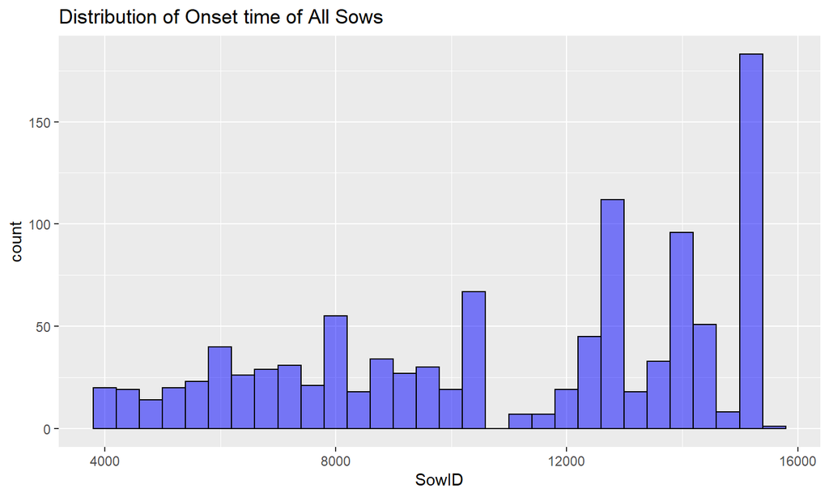

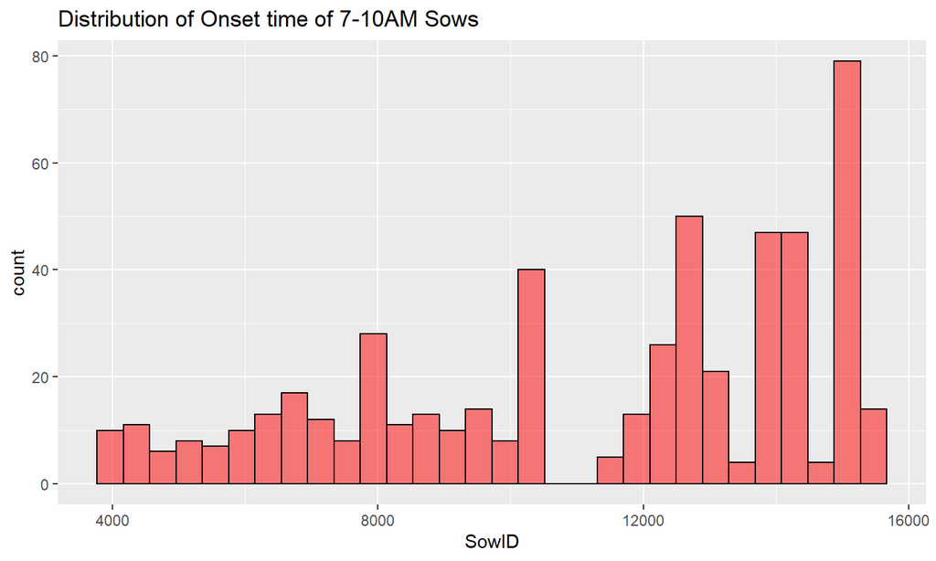

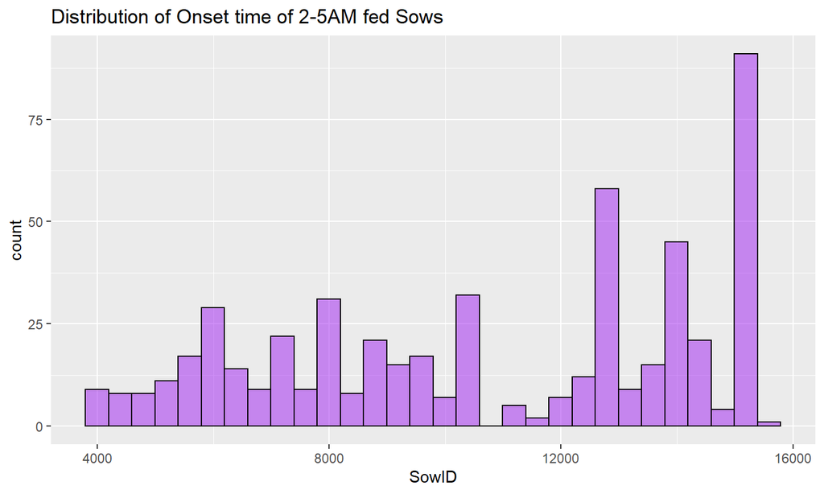

## SB% ~ Gestation Length

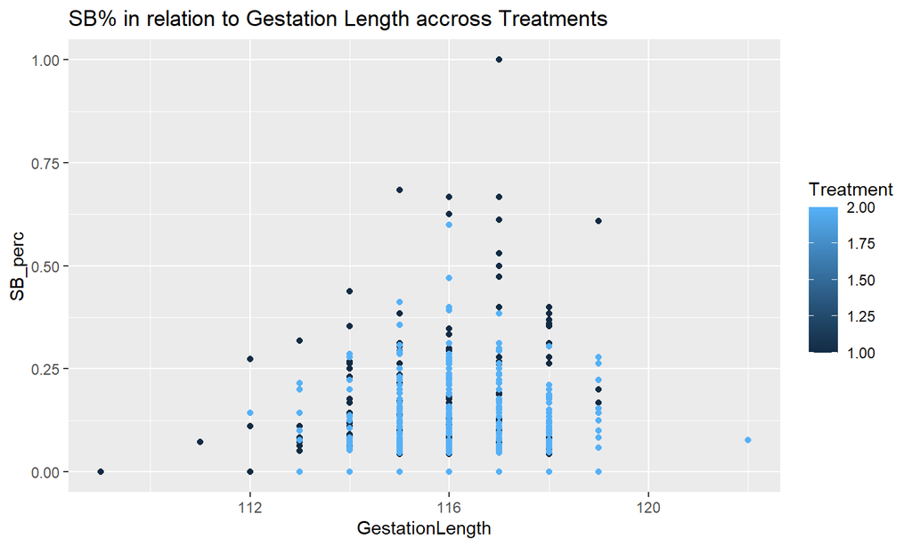

## TNB ~ Gestation Length

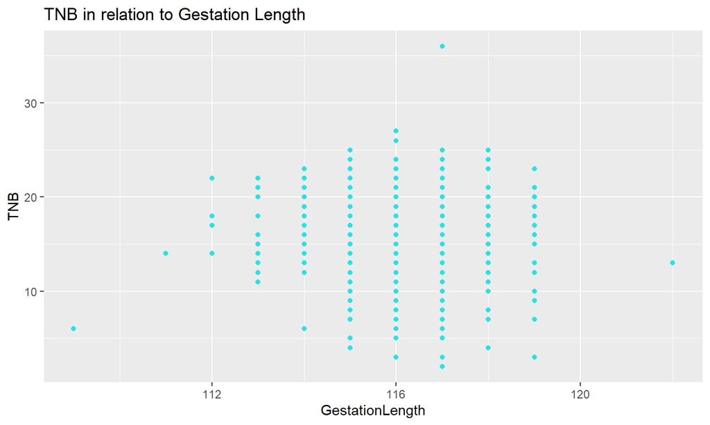

## Piglets observed ~ Onset

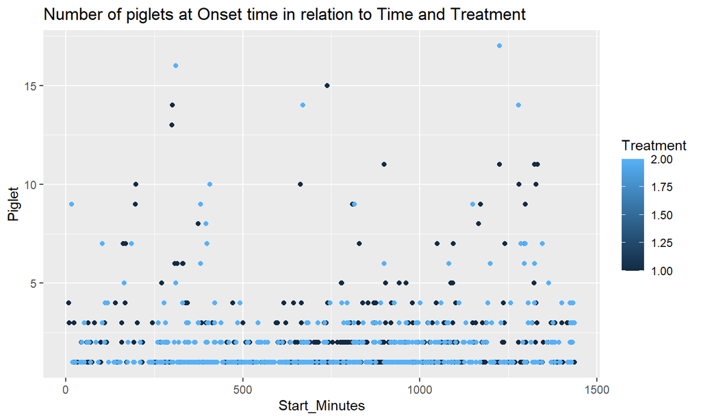

## TNB ~ Sow Age

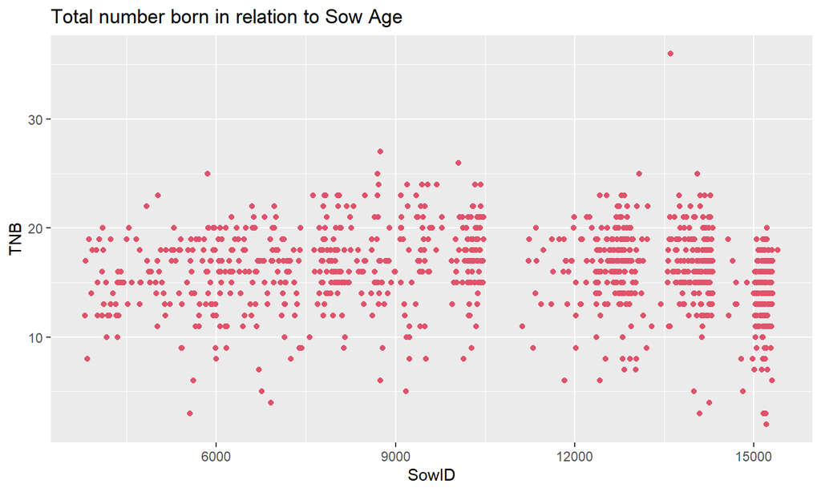

## Application: Project Overview

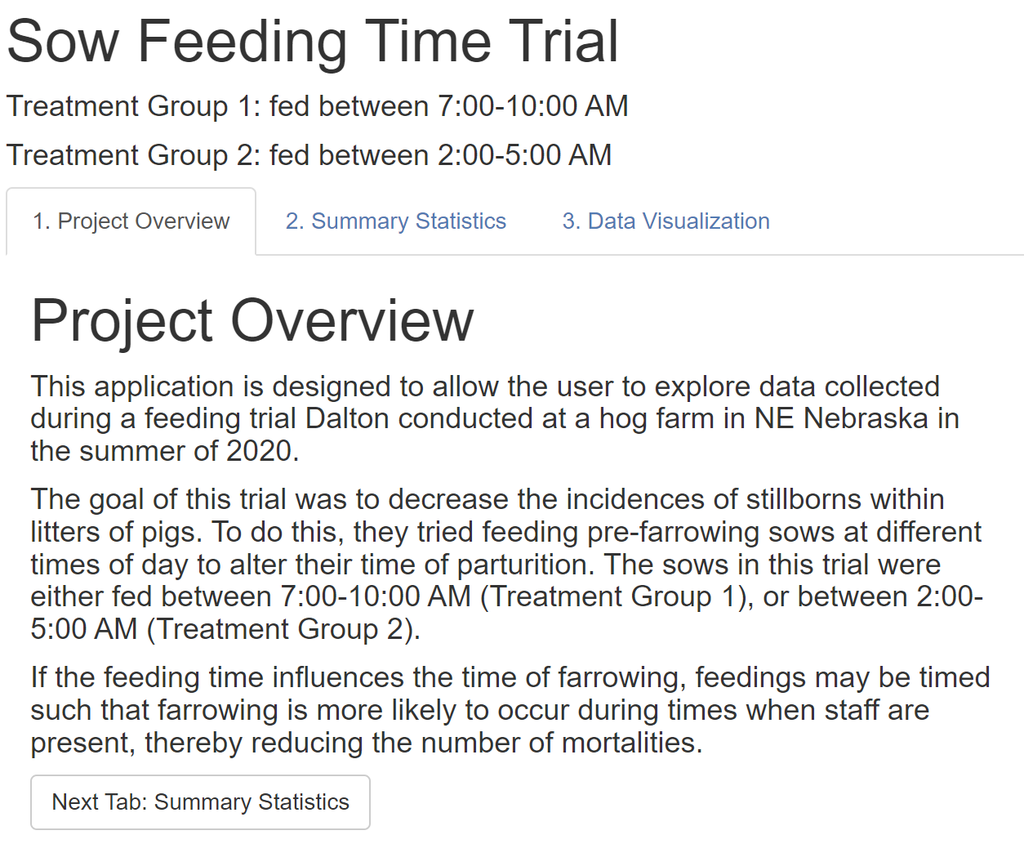

## Application: Summary Statistics

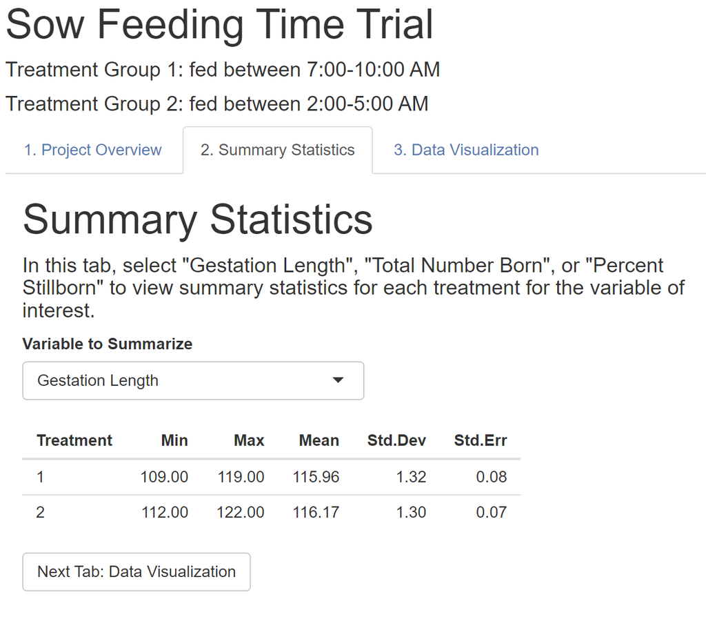

## Application: Data Visualization

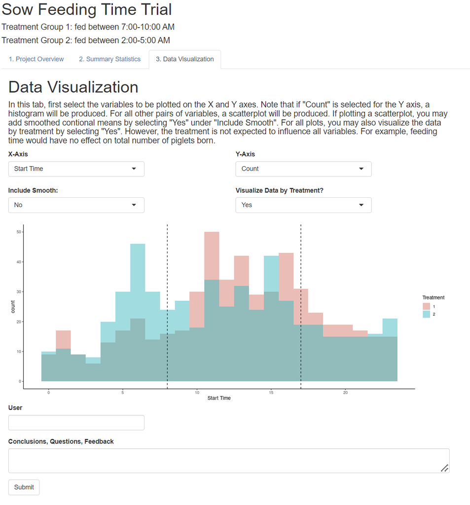

## Conclusion

In conclusion, results from this data set are not necessary clear without the use of statistical modeling. We are able to identify some trends via data visualization, however statistical inference on if our hypothesis is correct is unable to be completed. As always, it was interesting to see the impact certain traits had on others and the potential biological effects that may be at play in those circumstances.